# Capsule 2 - Ajuster et interpréter

MQT-2101 - Analyse et modélisation des données

## Pourquoi ça compte

Que signifie le coefficient de promotion?

Une direction veut comprendre l’association entre une promotion et les ventes, sans lui attribuer automatiquement une cause.

## Objectifs de la capsule

- Ajuster la régression sur les mois d’apprentissage.
- Interpréter le coefficient de promotion en dollars.
- Distinguer association conditionnelle et effet causal.

## Commencer par les moyennes observées

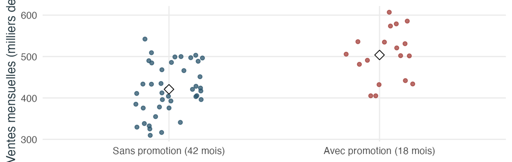

Les losanges indiquent 420 892 $ sans promotion et 503 764 $ avec promotion. D’où pourraient venir les 82 872 $ d’écart ?

## Pourquoi le calendrier entre dans le modèle

Tendance

Le compteur de mois distingue le début et la fin des cinq années. Les ventes peuvent évoluer au fil du temps.

Mois de l’année

Les indicatrices mensuelles permettent à janvier et à décembre d’avoir des niveaux différents, à tendance identique.

## Ajuster sur les mois disponibles

```r
modele_lm <- lm(
  ventes ~ tendance + promotion + prix_moyen +
    indice_confiance + mois,
  data = entrainement
)
coef(modele_lm)["promotionoui"]
```

Dans le projet guidé, l’entraînement s’arrête en décembre 2024. Le facteur promotion prend « non » comme référence.

## Lire trois lignes du même ajustement

| Terme | Variation considérée | Écart de ventes ajustées |
| --- | --- | --- |
| promotionoui | Passer de non à oui | +47 566 $ |
| prix_moyen | Augmenter de 1 $ par unité | −4 895 $ |
| indice_confiance | Augmenter de 1 point | +2 687 $ |

Lire chaque ligne en gardant fixes les autres termes du modèle. Les trois coefficients n’ont pas la même unité.

## Faire apparaître le coefficient par soustraction

Ventes ajustées sans promotion = B  
Ventes ajustées avec promotion = B + 47 566 $

B réunit la constante, la tendance, le mois, le prix et l’indice. Pour le même profil, soustraire B laisse 47 566 $. Dans les données brutes, ces termes changent aussi d’un mois à l’autre.

## Si le prix baisse en même temps

Hypothèse de calcul

Envisager à la fois une promotion et un prix inférieur de 1 $. Garder le mois, la tendance et l’indice identiques.

Calcul sous le modèle

La promotion ajoute 47 566 $ aux ventes ajustées. La baisse de prix ajoute 4 895 $ selon le modèle. Ensemble, l’écart prévu est d’environ 52 461 $.

## Que répondre au responsable des promotions ?

« Chaque promotion nous a rapporté 47 566 $. » Quelle partie de cette phrase dépasse ce que les données permettent de conclure ?

Le modèle compare des profils. Une campagne peut avoir été programmée pour un mois où la demande s’annonçait différente. Le coefficient seul ne permet pas d’isoler un gain causé par la campagne.

## À retenir

Référence

promotion « oui » comparée à « non »

Unité

différence de ventes en dollars par mois

Portée

une association conditionnelle, sans effet causal établi

## Production autonome 9.2

Ajustez la régression des ventes sur la tendance, le mois, la promotion, le prix et l’indice de confiance avec les 60 premiers mois. Interprétez le coefficient de promotion en dollars, à autres variables fixées, sans conclure à un effet causal.

Cette production se réalise une seule fois dans le rapport guidé.

### Auto-vérification

- Je nomme la catégorie de référence et les unités.
- Je distingue association conditionnelle et causalité.
- Je n’utilise pas les douze mois de validation pour ajuster le modèle.

## Références et crédits

Matériel du cours MQT-2101, Université Laval. Données fictives simulées pour l’enseignement.

Hyndman et Athanasopoulos (2021), *Forecasting: Principles and Practice*, 3e édition.